# Living Status

# 1 Description of DataSchema variable

The description of harmonised variable is the following:

- Short name: `living_status`
- Variable label: `Living status`
- Variable description: `The individual is dead or alive?`
- Domain: `Death`
- Value type: `categorical`
- Category coding:

| **Code** | **Category Label** |
| --- | --- |
| 0 | Alive |
| 1 | Dead |
| 2 | Dropout/unknown |

- Category missings:

| **Code** | **Category Label** |
| --- | --- |
| 991 | CAPI/interviewer error |
| 992 | Impute |
| 993 | Disable to measure |
| 994 | Not attempt/not done |
| 995 | Does not answer |
| 996 | Not applicable |
| 997 | Refuse |
| 998 | Do not know |
| 999 | Missing |

# 2 Data process

## 2.1 ELSA

### 2.1.1 Wave 1

#### 2.1.1.1 Harmonisation algorithm

It’s considered that at baseline all the individuals are alive. Therefore it is going to compute the variable with all the values as 0.

**R script:**

```r
ELSA_ds_w1 <- tibble(id = ELSA_w1_id$id)
ELSA_ds_w1$living_status <- 0
```

#### 2.1.1.2 Statistics of the new harmonised variable

Living status

| Sample size | Missing values |
| --- | --- |
| 12099 | 0 |

Category

|  | 0 |
| --- | --- |
| Frequency | 12099 |
| Percentage | 100 |

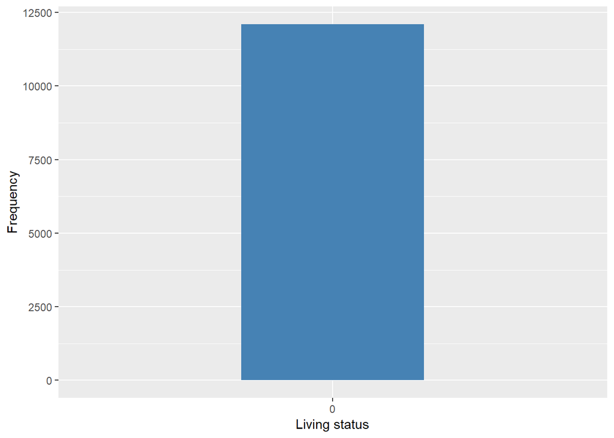

#### 2.1.1.3 Validation

### 2.1.2 Wave 2

#### 2.1.2.1 Study-specific variable description

| **Name** | `ydeath` | `iintdaty` |
| --- | --- | --- |
| **Label** | `Year of death` | `Year of Individual Interview` |
| **Table name** | `elsa_w2_hd` | `wave_2_ifs_derived_variables` |
| **Units** | `years` | `years` |
| **Missings** | `NA` |  |
| **Description** |  |  |

iintdaty

| Sample size | Missing values |
| --- | --- |
| 10020 | 588 |

Values

|  | 2004 | 2005 |
| --- | --- | --- |
| Frequency | 5240.0 | 4192.00 |
| Percentage | 52.3 | 41.84 |

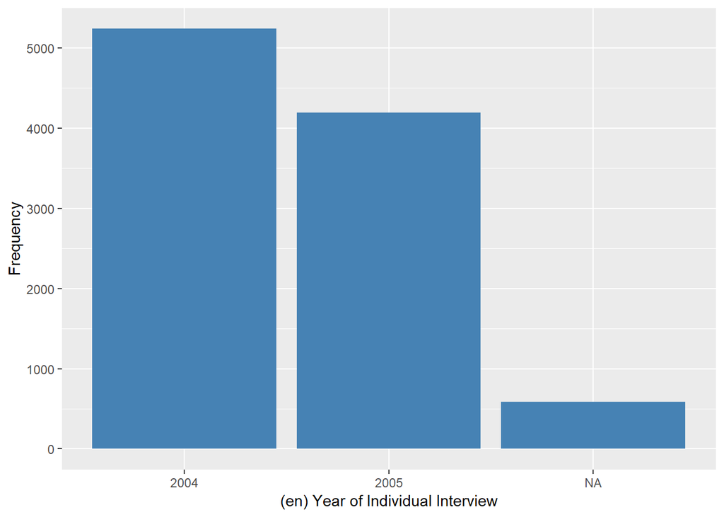

ydeath

| Sample size | Missing values |
| --- | --- |
| 10020 | 9432 |

Values

|  | 2002 | 2003 | 2004 | 2005 |
| --- | --- | --- | --- | --- |
| Frequency | 67.00 | 227.00 | 200 | 94.00 |
| Percentage | 0.67 | 2.27 | 2 | 0.94 |

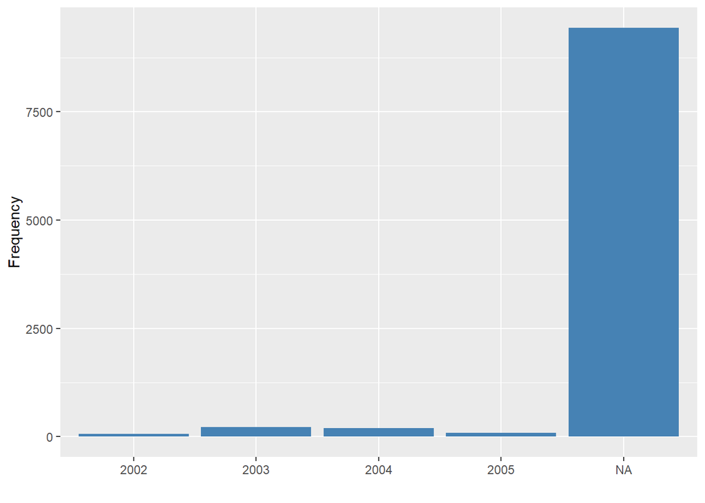

#### 2.1.2.2 Harmonisation algorithm

To compute the harmonized variable from the study-specific variable it has to be recoded as follows:

- `individuals that have date of interview into 0`
- `individuals with date of death into 1`
- `individuals without date of interview and death into 2`

**R script:**

```r
ELSA_ds_w2 <- tibble(id = ELSA_w2_LS$id)
ELSA_ds_w2$living_status <- NA
ELSA_ds_w2$living_status[!is.na(ELSA_w2_LS$ydeath)] <- 1
ELSA_ds_w2$living_status[!is.na(ELSA_w2_LS$iintdaty)] <- 0
ELSA_ds_w2$living_status[is.na(ELSA_w2_LS$ydeath) & is.na(ELSA_w2_LS$iintdaty)] <- 2
```

#### 2.1.2.3 Statistics of the new harmonised variable

Living status

| Sample size | Missing values |
| --- | --- |
| 10020 | 0 |

Category

|  | 0 | 1 |
| --- | --- | --- |
| Frequency | 9432.00 | 588.00 |
| Percentage | 94.13 | 5.87 |

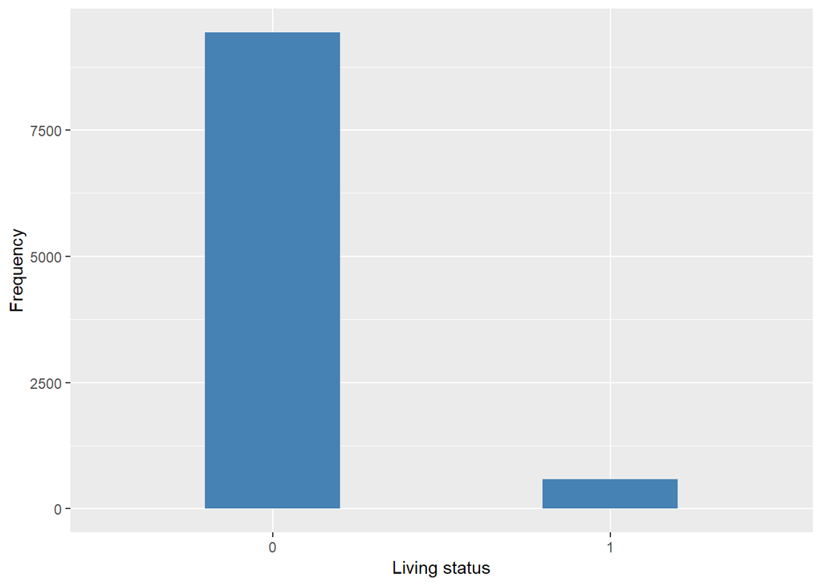

#### 2.1.2.4 Validation

### 2.1.3 Wave 3

#### 2.1.3.1 Study-specific variable description

| **Name** | `ydeath` | `iintdaty` |
| --- | --- | --- |
| **Label** | `Year of death` | `Year of Individual Interview: Year of date: TODAYS DATE` |
| **Table name** | `elsa_w3_hd` | `wave_3_ifs_derived_variables` |
| **Units** | `years` | `years` |
| **Missings** | `NA` |  |
| **Description** |  |  |

iintdaty

| Sample size | Missing values |
| --- | --- |
| 10290 | 519 |

Values

|  | 2006 | 2007 |
| --- | --- | --- |
| Frequency | 8099.00 | 1672.00 |
| Percentage | 78.71 | 16.25 |

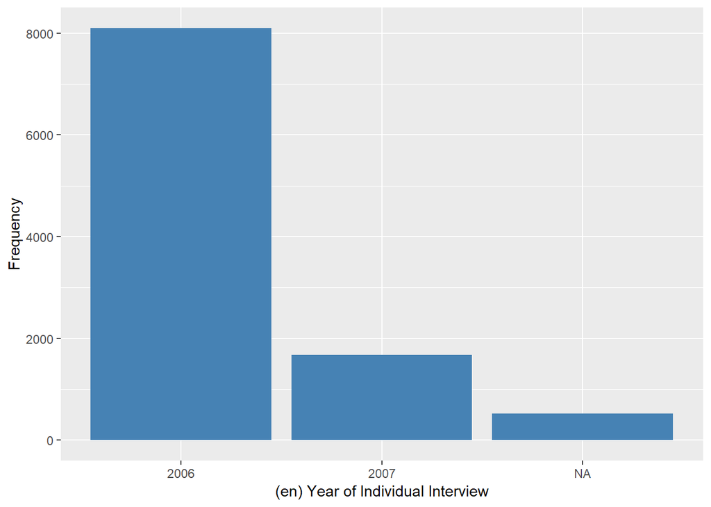

ydeath

| Sample size | Missing values |
| --- | --- |
| 10290 | 9771 |

Values

|  | 2004 | 2005 | 2006 | 2007 |
| --- | --- | --- | --- | --- |
| Frequency | 28.00 | 163.00 | 230.00 | 98.00 |
| Percentage | 0.27 | 1.58 | 2.24 | 0.95 |

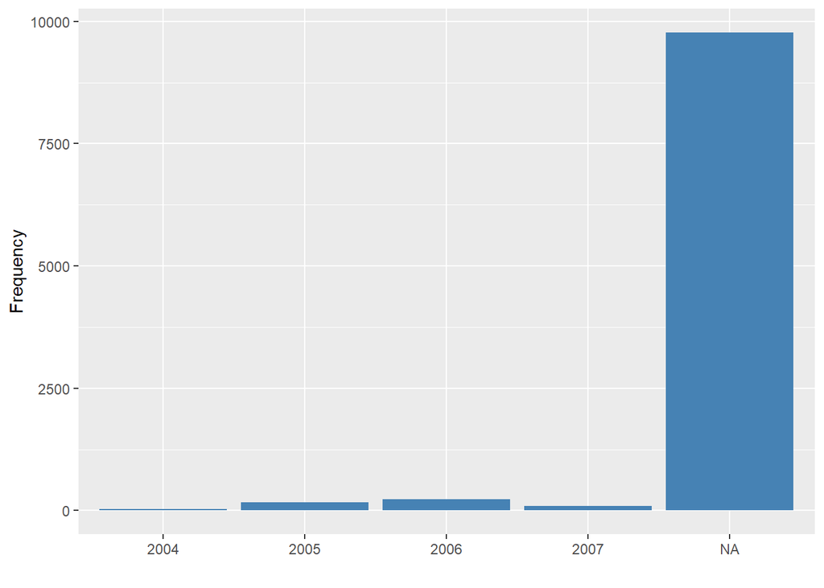

#### 2.1.3.2 Harmonisation algorithm

To compute the harmonized variable from the study-specific variable it has to be recoded as follows:

- `individuals that have date of interview into 0`
- `individuals with date of death into 1`
- `individuals without date of interview and death into 2`
- `individuals dead in previous waves into 1`

**R script:**

```r
ELSA_ds_w3 <- tibble(id = ELSA_w3_LS$id)
ELSA_ds_w3$living_status <- NA
ELSA_ds_w3$living_status[!is.na(ELSA_w3_LS$ydeath)] <- 1
ELSA_ds_w3$living_status[!is.na(ELSA_w3_LS$iintdaty)] <- 0
ELSA_ds_w3$living_status[is.na(ELSA_w3_LS$ydeath) & is.na(ELSA_w3_LS$iintdaty)] <- 2
ELSA_ds_w3 <- rbind(ELSA_ds_w3, ELSA_ds_w2 %>% filter(living_status == 1 & !id %in%
    ELSA_ds_w3$id))
```

#### 2.1.3.3 Statistics of the new harmonised variable

Living status

| Sample size | Missing values |
| --- | --- |
| 10878 | 0 |

Category

|  | 0 | 1 |
| --- | --- | --- |
| Frequency | 9771.00 | 1107.00 |
| Percentage | 89.82 | 10.18 |

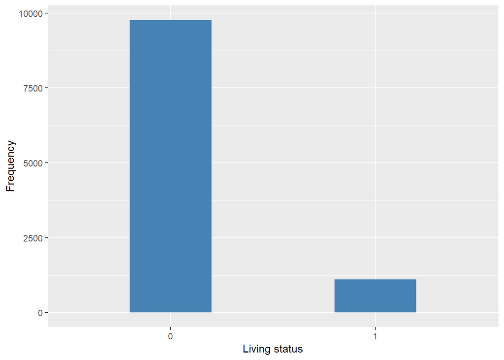

#### 2.1.3.4 Validation

### 2.1.4 Wave 4

#### 2.1.4.1 Study-specific variable description

| **Name** | `ydeath` | `iintdaty` |
| --- | --- | --- |
| **Label** | `Year of death` | `Year of Individual Interview: Year of date: TODAYS DATE` |
| **Table name** | `elsa_w4_hd` | `wave_4_ifs_derived_variables` |
| **Units** | `years` | `years` |
| **Missings** | `NA` |  |
| **Description** |  |  |

iintdaty

| Sample size | Missing values |
| --- | --- |
| 11624 | 574 |

Values

|  | 2008 | 2009 |
| --- | --- | --- |
| Frequency | 7127.00 | 3923.00 |
| Percentage | 61.31 | 33.75 |

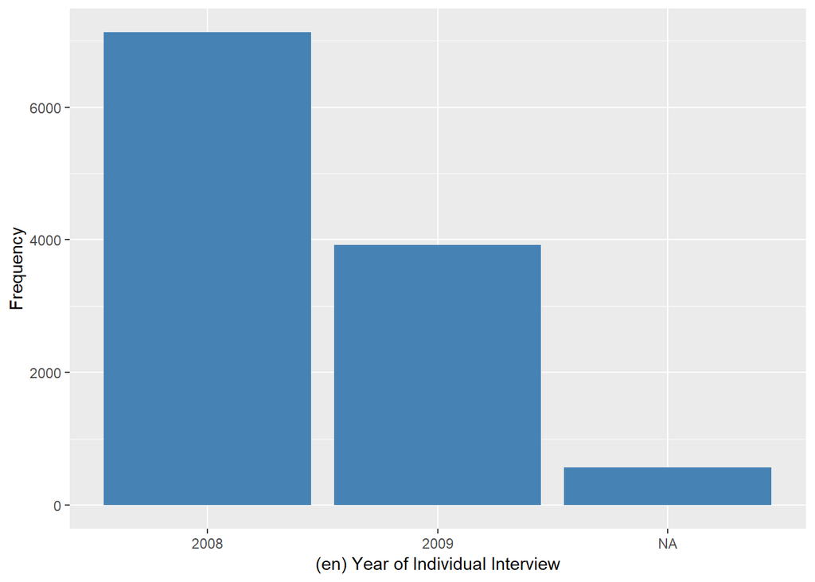

ydeath

| Sample size | Missing values |
| --- | --- |
| 11624 | 11050 |

Values

|  | 2006 | 2007 | 2008 | 2009 |
| --- | --- | --- | --- | --- |
| Frequency | 32.00 | 147.00 | 277.00 | 118.00 |
| Percentage | 0.28 | 1.26 | 2.38 | 1.02 |

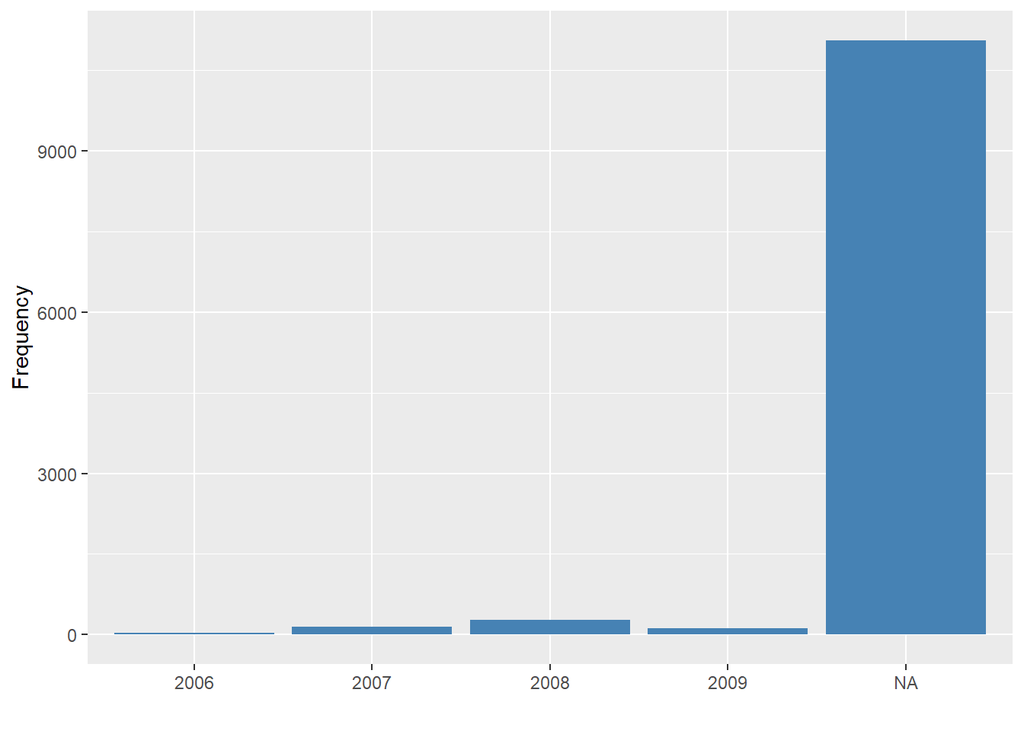

#### 2.1.4.2 Harmonisation algorithm

To compute the harmonized variable from the study-specific variable it has to be recoded as follows:

- `individuals that have date of interview into 0`
- `individuals with date of death into 1`
- `individuals without date of interview and death into 2`
- `individuals dead in previous waves into 1`

**R script:**

```r
ELSA_ds_w4 <- tibble(id = ELSA_w4_LS$id)
ELSA_ds_w4$living_status <- NA
ELSA_ds_w4$living_status[!is.na(ELSA_w4_LS$ydeath)] <- 1
ELSA_ds_w4$living_status[!is.na(ELSA_w4_LS$iintdaty)] <- 0
ELSA_ds_w4$living_status[is.na(ELSA_w4_LS$ydeath) & is.na(ELSA_w4_LS$iintdaty)] <- 2
ELSA_ds_w4 <- rbind(ELSA_ds_w4, ELSA_ds_w3 %>% filter(living_status == 1 & !id %in%
    ELSA_ds_w4$id))
```

#### 2.1.4.3 Statistics of the new harmonised variable

Living status

| Sample size | Missing values |
| --- | --- |
| 12731 | 0 |

Category

|  | 0 | 1 |
| --- | --- | --- |
| Frequency | 11050.0 | 1681.0 |
| Percentage | 86.8 | 13.2 |

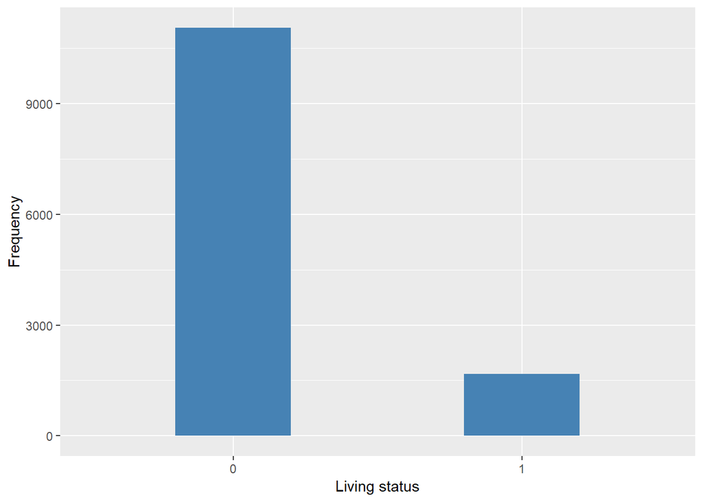

#### 2.1.4.4 Validation

### 2.1.5 Wave 5

#### 2.1.5.1 Study-specific variable description

| **Name** | `ydeath` | `iintdaty` |
| --- | --- | --- |
| **Label** | `Year of death` | `year of individual interview` |
| **Table name** | `elsa_w5_hd` | `wave_5_ifs_derived_variables` |
| **Units** | `years` | `years` |
| **Missings** | `NA` |  |
| **Description** |  |  |

iintdaty

| Sample size | Missing values |
| --- | --- |
| 10888 | 614 |

Values

|  | 2010 | 2011 |
| --- | --- | --- |
| Frequency | 7066.0 | 3208.00 |
| Percentage | 64.9 | 29.46 |

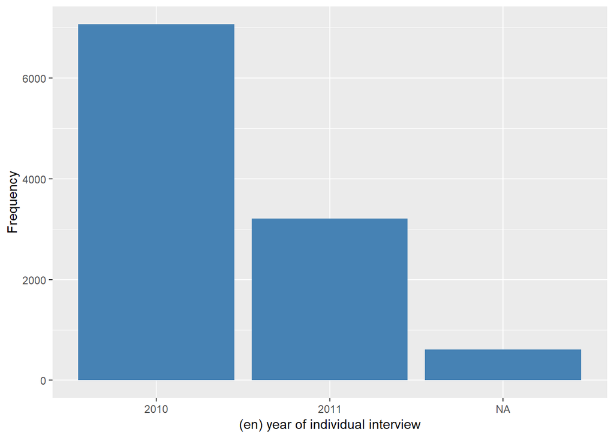

ydeath

| Sample size | Missing values |
| --- | --- |
| 10888 | 10274 |

Values

|  | 2008 | 2009 | 2010 | 2011 |
| --- | --- | --- | --- | --- |
| Frequency | 30.00 | 176.00 | 264.00 | 144.00 |
| Percentage | 0.28 | 1.62 | 2.42 | 1.32 |

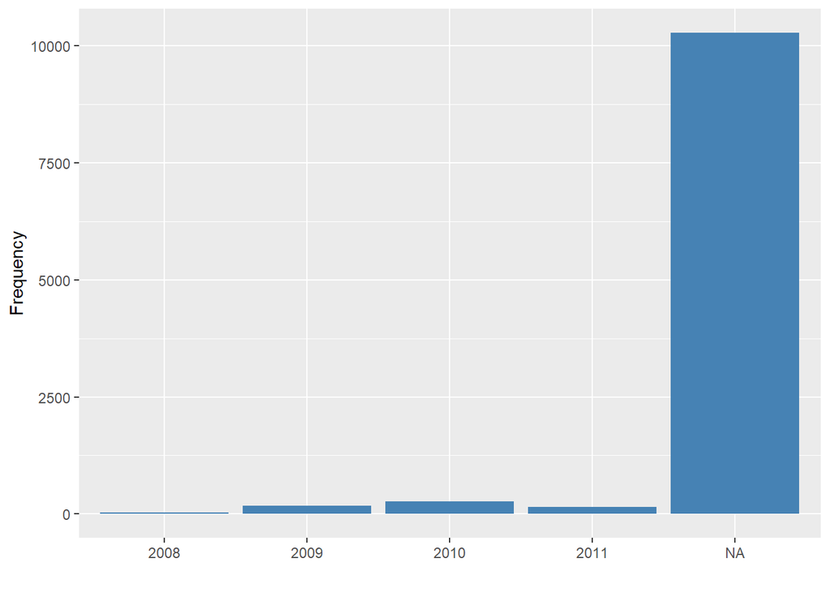

#### 2.1.5.2 Harmonisation algorithm

To compute the harmonized variable from the study-specific variable it has to be recoded as follows:

- `individuals that have date of interview into 0`
- `death individuals in previous waves into 1`
- `individuals without date of interview either as was not dead in previous waves into 2`
- `individuals dead in previous waves into 1`

**R script:**

```r
ELSA_ds_w5 <- tibble(id = ELSA_w5_LS$id)
ELSA_ds_w5$living_status <- NA
ELSA_ds_w5$living_status[!is.na(ELSA_w5_LS$ydeath)] <- 1
ELSA_ds_w5$living_status[!is.na(ELSA_w5_LS$iintdaty)] <- 0
ELSA_ds_w5$living_status[is.na(ELSA_w5_LS$iintdaty) & is.na(ELSA_w5_LS$ydeath)] <- 2
ELSA_ds_w5 <- rbind(ELSA_ds_w5, ELSA_ds_w4 %>% filter(living_status == 1 & !id %in%
    ELSA_ds_w5$id))
```

#### 2.1.5.3 Statistics of the new harmonised variable

Living status

| Sample size | Missing values |
| --- | --- |
| 12569 | 0 |

Category

|  | 0 | 1 |
| --- | --- | --- |
| Frequency | 10274.00 | 2295.00 |
| Percentage | 81.74 | 18.26 |

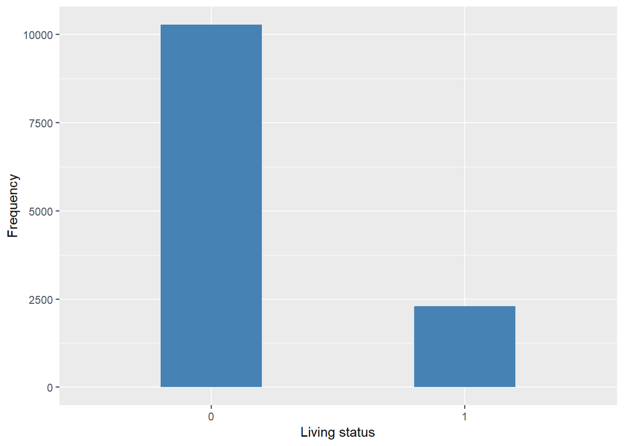

#### 2.1.5.4 Validation

### 2.1.6 Wave 6

#### 2.1.6.1 Study-specific variables

| **Name** | `ydeath` | `iintdaty` | `mortstat` |
| --- | --- | --- | --- |
| **Label** | `Year of death` | `year of individual interview` | `Mortality status from ONS -updated Feb 2012` |
| **Table name** | `elsa_w6_hd` | `wave_6_ifs_derived_variables` | `index_file_wave_0-wave_5_v2` |
| **Units** | `years` | `years` | `-2 = Dead - information from other sources` `-1 = No permission to check` `0 = Permission given but no trace` `1 = Alive` `2 = Dead` |
| **Missings** | `NA` |  |  |
| **Description** |  |  |  |

iintdaty

| Sample size | Missing values |
| --- | --- |
| 13357 | 2756 |

Values

|  | 2012 | 2013 |
| --- | --- | --- |
| Frequency | 9047.00 | 1554.00 |
| Percentage | 67.73 | 11.63 |

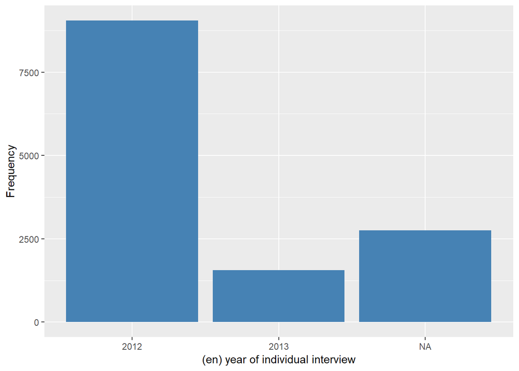

ydeath

| Sample size | Missing values |
| --- | --- |
| 13357 | 13052 |

Values

|  | 2010 | 2011 | 2012 |
| --- | --- | --- | --- |
| Frequency | 26.00 | 172.00 | 107.0 |
| Percentage | 0.19 | 1.29 | 0.8 |

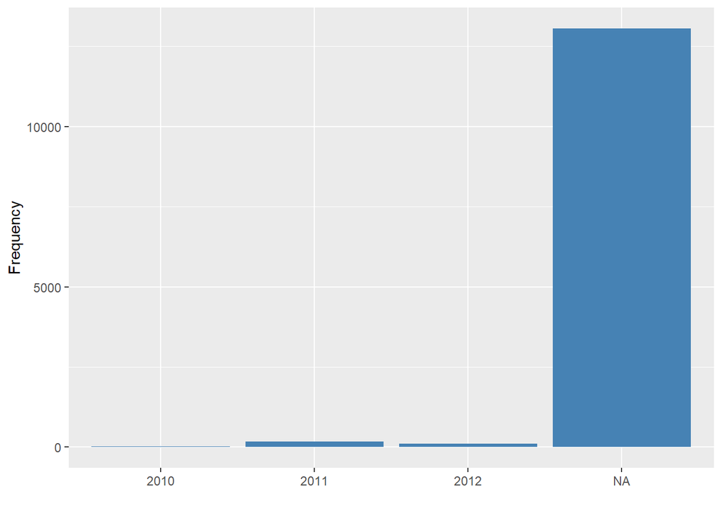

mortstat

| Sample size | Missing values |
| --- | --- |
| 13357 | 10638 |

Values

|  | -2 | 2 |
| --- | --- | --- |
| Frequency | 236.00 | 2483.00 |
| Percentage | 1.77 | 18.59 |

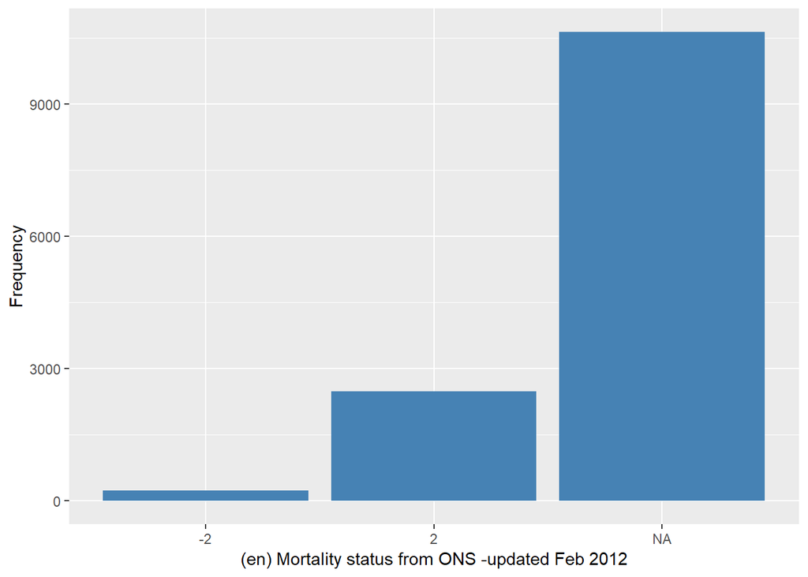

#### 2.1.6.2 Harmonisation algorithm

To compute the harmonized variable from the study-specific variable it has to be recoded as follows:

- `individuals that have date of interview into 0`
- `individuals with date of death into 1`
- `individuals without date of interview and death into 2`
- `individuals dead in previous waves into 1`

**R script:**

```r
ELSA_ds_w6 <- tibble(id = ELSA_w6_LS$id)
ELSA_ds_w6$living_status <- 2
ELSA_ds_w6$living_status[which(!is.na(ELSA_w6_LS$ydeath) | ELSA_w6_LS$mortstat %in%
    c(-2, 2))] <- 1
ELSA_ds_w6$living_status[!is.na(ELSA_w6_LS$iintdaty)] <- 0
ELSA_ds_w6 <- rbind(ELSA_ds_w6, ELSA_ds_w5 %>% filter(living_status == 1 & !id %in%
    ELSA_ds_w6$id))
```

#### 2.1.6.3 Statistics of the new harmonised variable

Living status

| Sample size | Missing values |
| --- | --- |
| 13359 | 0 |

Category

|  | 0 | 1 |
| --- | --- | --- |
| Frequency | 10601.00 | 2758.00 |
| Percentage | 79.35 | 20.65 |

Type of missing

|  | 991 | 992 | 993 | 994 | 995 | 996 | 997 | 998 | 999 | NA |
| --- | --- | --- | --- | --- | --- | --- | --- | --- | --- | --- |
| Frequency | 0 | 0 | 0 | 0 | 0 | 0 | 0 | 0 | 0 | 0 |
| Percentage | 0 | 0 | 0 | 0 | 0 | 0 | 0 | 0 | 0 | 0 |

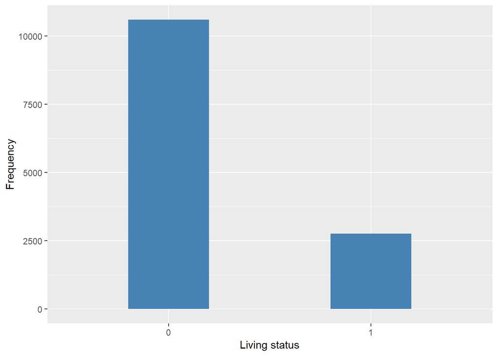

#### 2.1.6.4 Validation

### 2.1.7 Wave 7

#### 2.1.7.1 Study-specific variables

| **Name** | `iintdaty` |
| --- | --- |
| **Label** | `Year of Individual Interview` |
| **Table name** | `wave_7_elsa_data` |
| **Units** | `years` |
| **Description** |  |

iintdaty

| Sample size | Missing values |
| --- | --- |
| 12385 | 2719 |

Values

|  | 2014 | 2015 |
| --- | --- | --- |
| Frequency | 7695.00 | 1971.00 |
| Percentage | 62.13 | 15.91 |

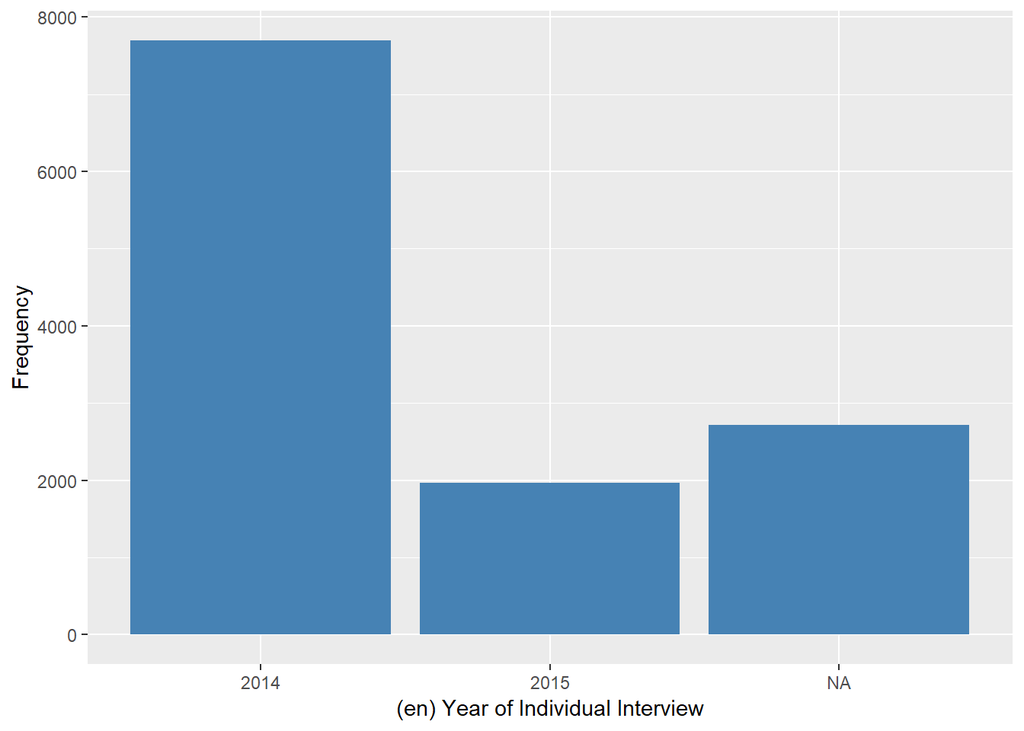

#### 2.1.7.2 Harmonisation algorithm

To compute the harmonized variable from the study-specific variable it has to be recoded as follows:

- `individuals that have date of interview into 0`
- `individuals without date of interview into 2`
- `individuals dead in previous waves into 1`

**R script:**

```r
ELSA_ds_w7 <- tibble(id = ELSA_w7_yinter$id)
ELSA_ds_w7$living_status <- 2
ELSA_ds_w7$living_status[which(ELSA_w7_yinter$mortstat %in% c(-2, 2))] <- 1
ELSA_ds_w7$living_status[!is.na(ELSA_w7_yinter$iintdaty)] <- 0
ELSA_ds_w7 <- rbind(ELSA_ds_w7, ELSA_ds_w6 %>% filter(living_status == 1 & !id %in%
    ELSA_ds_w7$id))
```

#### 2.1.7.3 Statistics of the new harmonised variable

Living status

| Sample size | Missing values |
| --- | --- |
| 12427 | 0 |

Category

|  | 0 | 1 |
| --- | --- | --- |
| Frequency | 9666.00 | 2761.00 |
| Percentage | 77.78 | 22.22 |

Type of missing

|  | 991 | 992 | 993 | 994 | 995 | 996 | 997 | 998 | 999 | NA |
| --- | --- | --- | --- | --- | --- | --- | --- | --- | --- | --- |
| Frequency | 0 | 0 | 0 | 0 | 0 | 0 | 0 | 0 | 0 | 0 |
| Percentage | 0 | 0 | 0 | 0 | 0 | 0 | 0 | 0 | 0 | 0 |

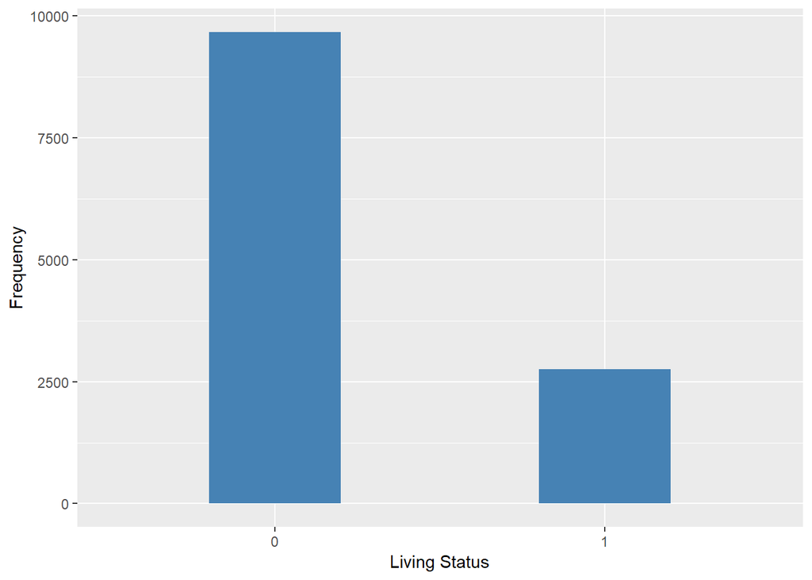

#### 2.1.7.4 Validation

## 2.2 Summary of descriptive statistics of the harmonised variable accross populations and waves

Two tables are generated:

1. Percentages of categories in each harmonised variable.
2. Frequencies and percentages of individuals with different trajectories.

Living status

| val | label | W1 | W2 | W3 | W4 | W5 | W6 | W7 |
| --- | --- | --- | --- | --- | --- | --- | --- | --- |
| 0 | Alive | 100 | 94.13 | 89.82 | 86.8 | 81.74 | 79.35 | 77.78 |
| 1 | Dead | 0 | 5.87 | 10.18 | 13.2 | 18.26 | 20.65 | 22.22 |
| 2 | Dropout | 0 | 0 | 0 | 0 | 0 | 0 | 0 |
| 991 | CAPI interviewer error | 0 | 0 | 0 | 0 | 0 | 0 | 0 |
| 992 | Impute | 0 | 0 | 0 | 0 | 0 | 0 | 0 |
| 993 | Disable to measure | 0 | 0 | 0 | 0 | 0 | 0 | 0 |
| 994 | Not attempt not done | 0 | 0 | 0 | 0 | 0 | 0 | 0 |
| 995 | Does not answer | 0 | 0 | 0 | 0 | 0 | 0 | 0 |
| 996 | Not applicable | 0 | 0 | 0 | 0 | 0 | 0 | 0 |
| 997 | Refuse | 0 | 0 | 0 | 0 | 0 | 0 | 0 |
| 998 | Do not know | 0 | 0 | 0 | 0 | 0 | 0 | 0 |
| 999 | Missing | 0 | 0 | 0 | 0 | 0 | 0 | 0 |
| NA | NA | 0 | 0 | 0 | 0 | 0 | 0 | 0 |
| n | sample size | 12099 | 10020 | 10878 | 12731 | 12569 | 13359 | 12427 |

| val | frq | raw.prc |
| --- | --- | --- |
| 0000000 | 4381 | 23.70 |
| 0000001 | 2 | 0.01 |
| 000000NA | 679 | 3.67 |
| 0000011 | 206 | 1.11 |
| 00000NA0 | 71 | 0.38 |
| 00000NANA | 294 | 1.59 |
| 0000111 | 328 | 1.77 |
| 0000NA00 | 65 | 0.35 |
| 0000NA0NA | 36 | 0.19 |
| 0000NA11 | 20 | 0.11 |
| 0000NANA0 | 16 | 0.09 |
| 0000NANANA | 269 | 1.45 |
| 0001111 | 364 | 1.97 |
| 000NA000 | 121 | 0.65 |
| 000NA00NA | 63 | 0.34 |
| 000NA011 | 11 | 0.06 |
| 000NA0NA0 | 15 | 0.08 |
| 000NA0NANA | 39 | 0.21 |
| 000NA111 | 58 | 0.31 |
| 000NANA00 | 34 | 0.18 |
| 000NANA0NA | 20 | 0.11 |
| 000NANA11 | 24 | 0.13 |
| 000NANANA0 | 6 | 0.03 |
| 000NANANANA | 491 | 2.66 |
| 0011111 | 396 | 2.14 |
| 00NA0000 | 117 | 0.63 |
| 00NA000NA | 34 | 0.18 |
| 00NA0011 | 8 | 0.04 |
| 00NA00NA0 | 5 | 0.03 |
| 00NA00NANA | 24 | 0.13 |

[output cut: 133 more lines]

# 3 Quality estimation

The ELSA sample has been refreshed four times, at waves 3, 4, 6 and 7. The new individuals interviewed are either new participants or partners. For this reason, there are new individuals interviewed even at waves that there wasn’t refreshment.

At wave 7 we do not have information about dead individuals.